## 跟隨網絡

首先可以利用議題篩選功能選擇特定的議題跟隨網絡圖

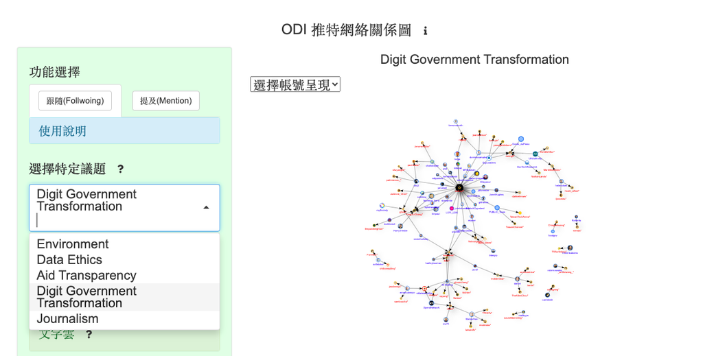

接著可以利用下方的跟隨排行找出網絡中跟隨最多台灣帳號的 ODI 上線

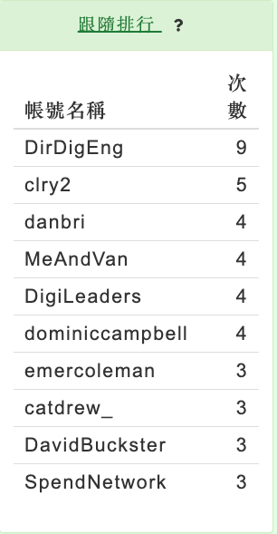

再利用網絡上的篩選功能，在較複雜的網絡中重點標示出點選的帳號，在此我們觀察跟隨排行中第一名的「DirDigEng」作為重點標示的帳號

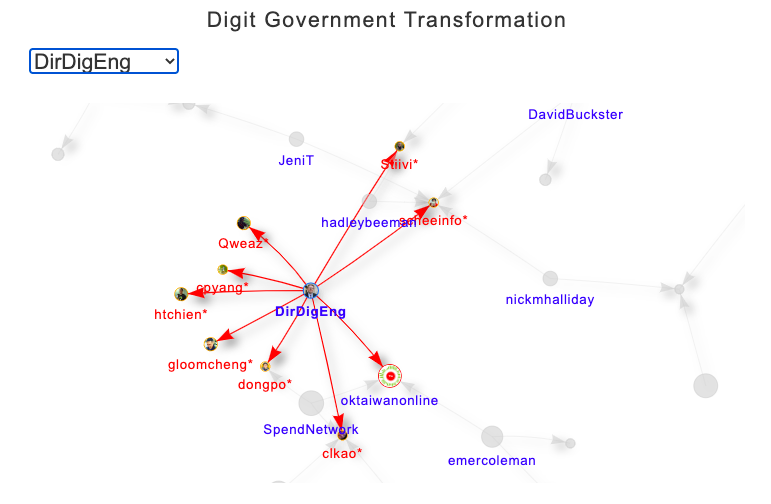

點選網絡中的節點，可以從資訊欄中看到該帳號的自我介紹，若要獲取該帳號進一步的資訊，也可以點選帳號名稱，直接連結至其推特帳號中

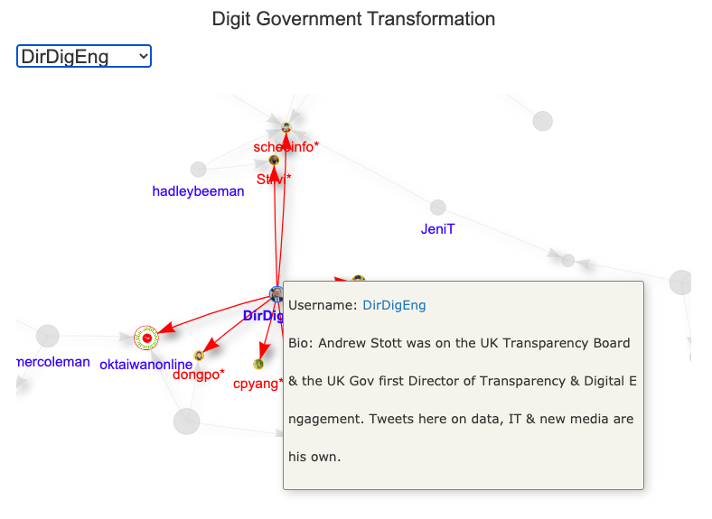

如圖所示，在數位政府轉型的議題中，跟隨最多台灣帳號的是 Andrew Stott， 他是英國政府數位建設相關部門的主任

[figure not shown]

使用者也可以從被追蹤排行找到重要的台灣帳號

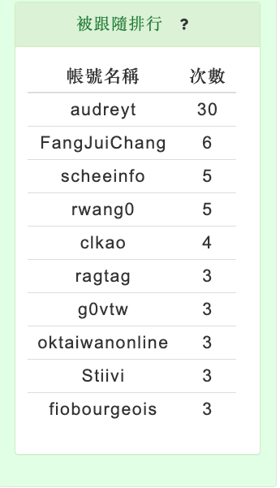

我們選擇第二名的「FangJuiChang」作為測試對象，因為第一名的帳號「audreyt」是台灣政務委員唐鳳，其重要性不言而喻

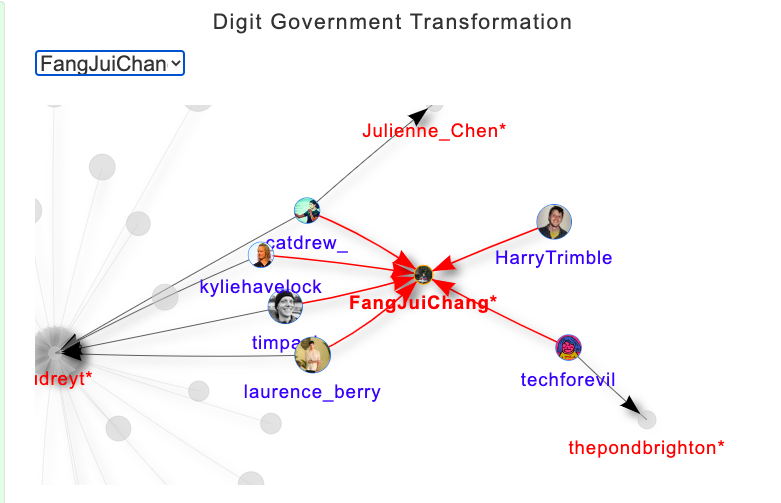

「FangJuiChang」和數位政府轉型的關聯在於其曾任職於推動公民培力創新的組織

[figure not shown]

## 提及網絡

首先可以透過中心節點篩選功能，簡化右圖的網絡複雜度

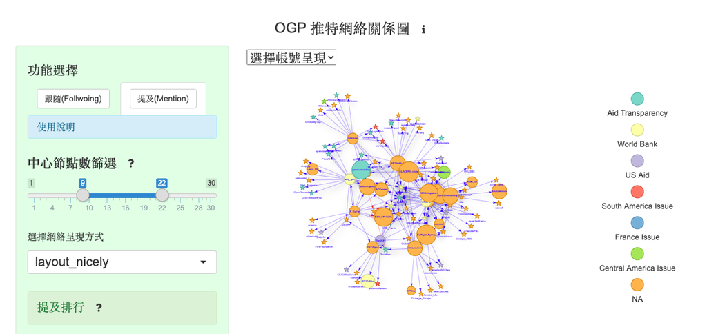

接著同樣從提及排行與被提及排行切入，選擇要再網絡中重點標示的重要帳號

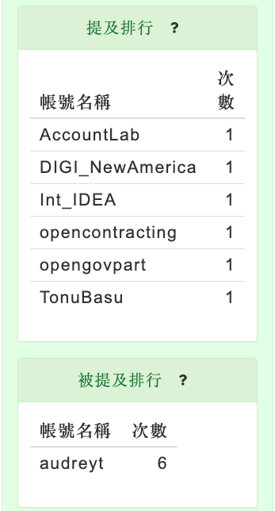

在此範例中，只有唐鳳有被其他帳號提及，因此我們在網絡圖上重點標示出提及過唐鳳的帳號

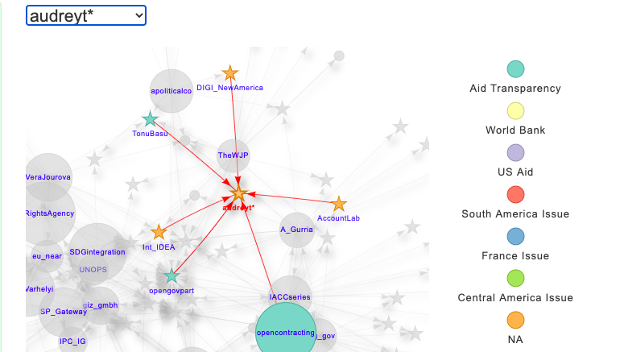

點選提及的關係線後，可以點選 Link 觀看提及唐鳳的推文內容

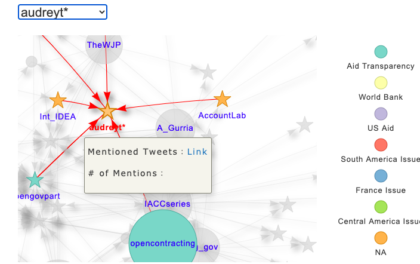

點選「AccountLab」提及的唐鳳文章後，可以發現唐鳳確實有何該帳號舉行過線上會議

[figure not shown]

在本次研究結果中，我們也逆向操作，測試現實發生的事件，是否能夠在網絡中被觀測到，唐鳳在今年 5/20 曾與 OGP 、國際透明組織[進行線上會議](https://www.cna.com.tw/news/firstnews/202105210011.aspx)，在提及網絡圖上我們可以發現 OGP(opengovpart) 確實有提及過唐鳳

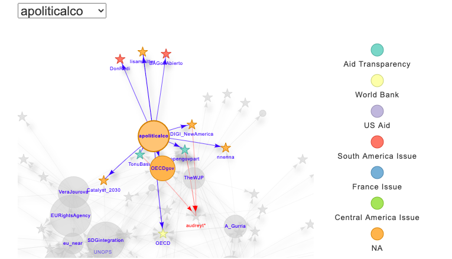

且該篇提及文章正是在分享 5/20 線上會議的訊息

[figure not shown]